# mechmodels_mle_ecosem_W25

2025-02-12

```r
library(DHARMa)
library(glmmTMB)
```

(The following is adapted from Tim Essington’s class, Introduction to Quantitative Ecology. His book of the same name is a fantastic resource for beginning modelers.)

Every year around this time local and national organizations begin to track the spread of influenza. Suppose that you are an employee of the Department of Public Health for New York City and you are monitoring local hospitalizations for influenza cases. Every year, the flu vaccine involves a high degree of guesswork for which strains will be dominant this year. If the CDC guesses well, then flu season is relatively mild, but if they guess poorly then the flu season can be much worse.

You have received counts of the number of daily influenza hospitalizations. Load and run the data below to get a look at it.

## Load the data

```r
load(file='flu.rda')
```

## Plot the data

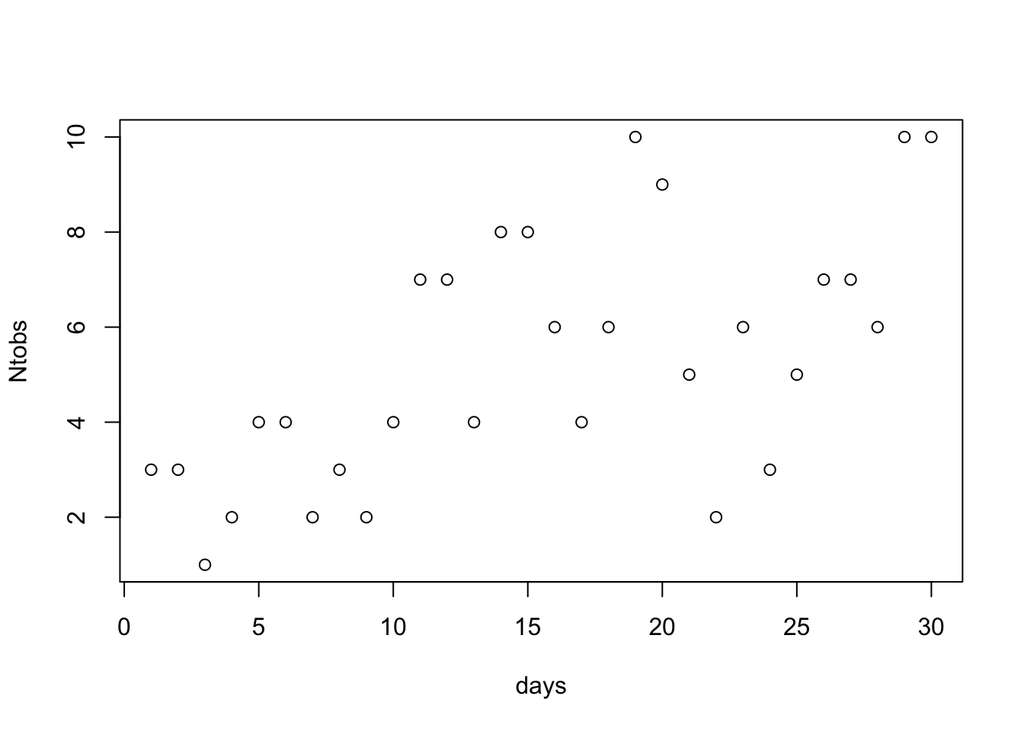

```r
days <- thedata$Day
Ntobs <- thedata$NoHospitalizations

plot(days, Ntobs)
```

Notice that there’s a lot of variability here. We’ll come back to that later.

## Correlative model

If you had no knowledge of how disease spread works, and we just wanted to use a purely statistical model, we can pretty easily do that. Run the code below.

```r
# Run a linear model
lm <- lm(Ntobs ~ days, data = thedata)
summary(lm)
```

```
##
## Call:
## lm(formula = Ntobs ~ days, data = thedata)
##
## Residuals:
##     Min      1Q  Median      3Q     Max
## -4.4553 -1.4738 -0.2238  1.7247  4.0933
##
## Coefficients:
##             Estimate Std. Error t value Pr(>|t|)
## (Intercept)  2.43218    0.79029   3.078 0.004632 **
## days         0.18287    0.04452   4.108 0.000314 ***
## ---
## Signif. codes:  0 '***' 0.001 '**' 0.01 '*' 0.05 '.' 0.1 ' ' 1
##
## Residual standard error: 2.11 on 28 degrees of freedom
## Multiple R-squared:  0.376,  Adjusted R-squared:  0.3538
## F-statistic: 16.88 on 1 and 28 DF,  p-value: 0.0003144
```

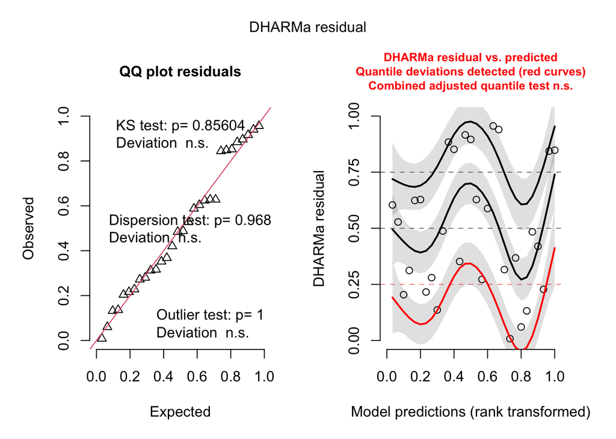

```r
# Simulate residuals
tst_simres <- simulateResiduals(lm) #DHARMa
plot(tst_simres)
```

This model actually kind of works. But…

## Fitting a mechanistic model to our data using maximum likelihood estimation

We know as biologists though (and people who have lived through a pandemic) that hospitalizations don’t necessarily increase linearly. Your data is highly noisy, but you know that real cases are growing exponentially in a highly predictable manner. In fact, you think the cases change according the following model:

$$\frac{dN(t)}{dt} = rN(t)$$
where r is the rate of growth and N(0) is the initial number of influenza cases, and t is day. The solution to this expression can be written as:

$$N(t) = N(0)e^{rt}$$
By setting t = 1, 2, 3, …. 30, you can calculate the predicted number of flu cases for each day.

So, you would like to use your data to estimate the daily growth rate r (and hte N0) of flu cases. Given that your data is noisy, it would be wise to incorporate an element of uncertainty when you’re fitting your model to your data that also fits the structure of your data, much like you would in fitting a generalized linear model. Given the structure of the data (discrete counts of events over a continuous window) you will treat your observations as random variables, described by a Poisson probability function:

$$Y_i \sim Poisson(\lambda = N(t))$$
where lambda refers to the mean of the Poisson probability function.

We can estimate the daily growth rate r by working sort of in reverse: given an r value, assuming it’s the “true” one, how likely is the data that we have. Through this framework, we use a function optim that uses a numerical algorithm to search an r value that maximizes the likelihood of the data.

Optim just looks to maximize/minimize the output of a function that we put in, so we need to make a function first.

```r
## inputs are "pars", which are starting parameters (values for N0 and r) and following parameters that optim will put in; "Ntobs", which is our data, and "t" or days since N0

flu.nll <- function(pars, Ntobs, t) {
  # pars is a vector that contains our N0 and r values; we're calling both and putting them into variables
N0 <- pars[1]
r <- pars[2]
# getting the number of days in our dataset
ndays <- length(Ntobs)
# creating a list of Nt values for our function output ahead of time as it makes the algorithm go faster
Nt <- rep(NA, times = ndays)
# experimenting with initial case number and putting htat in our NT list
Nt[1] <- N0
# running a loop to get Nt values with our parameters
for (i in 1:ndays) Nt[i] <- N0 * exp(r*t[i])
# calculate negative log likelihood of of this data we generated (Nt) given our data (Ntobs)
nll <- -sum(dpois(Ntobs, lambda = Nt, log = TRUE))
return(nll)
}
```

### Getting our parameters

```r
## 2 is our starting N0 for the data, and 0.01 is our starting r. This seems reasonable given what the data looks like.
start.pars <- c(2, 0.01)
## Run optim with our starting parameters, our negative log likelihood function, and our data to get parameters
  ### You can use different methods for optim, I just used this one.
soln <- optim(par = start.pars, fn = flu.nll, Ntobs = Ntobs,
t = days, method = "Nelder-Mead")
print(soln$par)
```

```
## [1] 2.90550013 0.03537323
```

### How does our model look against the data?

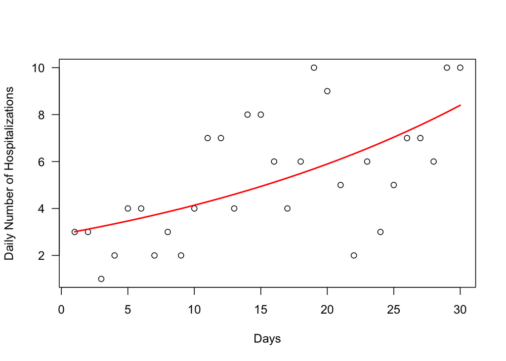

```
## integer(0)
```

```r
predict <- soln$par[1]*exp(soln$par[2]*days)
plot(days, Ntobs, type = "p", xlab = "Days", ylab = "Daily Number of Hospitalizations", las = 1) +
  lines(days, predict, lwd = 2, col = "Red")
```

Looks like a pretty good fit! We now have used maximum likelihood estimation to statistically fit mechanistic model parameters to our data.